# Modeling and Optimization

# Minimum Cost Flow and Its Special Cases

## The Minimum Cost Flow Problem

$$\begin{alignat*}{3}
\min~ & \rlap{\textstyle\sum_{(i,j)} c_{ij}\,x_{ij}} \\[4pt]
\text{s.t.}~ & \textstyle\sum_j x_{ij} - \sum_j x_{ji} & \quad & {}= b_i && \qquad \text{every node } i \\
& x_{ij} & \quad & {}\le u_{ij} && \qquad \text{every arc} \\
& x_{ij} & \quad & {}\ge 0 && \qquad \text{every arc}
\end{alignat*}$$

- ${c_{ij}}$: cost per unit; ${u_{ij}}$: capacity
- ${b_i}$: net supply; positive at supply nodes, negative at demand nodes
- One row per node: **out minus in**

**Feasibility needs balance**

${\sum_i b_i = 0}$: the balance rows add up to 0 on the left. Extra supply goes to a dummy demand node.

## Integer Flows for Free

**Integer solutions property**

If every ${b_i}$ and ${u_{ij}}$ is an integer, every basic feasible solution is integer: the simplex method returns integer flows with no integer constraint.

**Why.** The basic arcs form a spanning tree, and flows on a tree follow one leaf at a time by adding and subtracting. Distribution Unlimited, DC→W2 at its capacity of 80:

- Leaf F2: ${x_{F2,DC} = 40}$. W2: ${x_{W2,W1} = 80 - 60 = 20}$
- W1: ${x_{F1,W1} = 30 - 20 = 10}$. DC: ${x_{F1,DC} = 80 - 40 = 40}$

## Five Special Cases

Each is a minimum cost flow, so each has integer optimal solutions

| Special case | Net supplies | Arcs |
| --- | --- | --- |
| Transportation | Sources +, destinations − | Source → destination |
| Assignment | Person +1, task −1 | Person → task |
| Transshipment | Middle nodes 0 | No capacities |
| Shortest path | Origin +1, destination −1 | Lengths as costs |
| Maximum flow | All 0 | Add T→O at cost −1 |

## Where Minimum Cost Flows Appear

| Application | Supply nodes | Transshipment nodes | Demand nodes |
| --- | --- | --- | --- |
| Distribution | Factories | Warehouses | Customers |
| Food aid (WFP) | Suppliers | Ports, warehouses | Beneficiaries |
| Solid waste | Waste sources | Processing plants | Landfills |
| Supply | Vendors | Warehouses | Plants |
| Cash flow | Cash in, by date | Short-term investments | Cash out, by date |

# A Minimum Cost Flow Model: Distribution Unlimited

## The Network

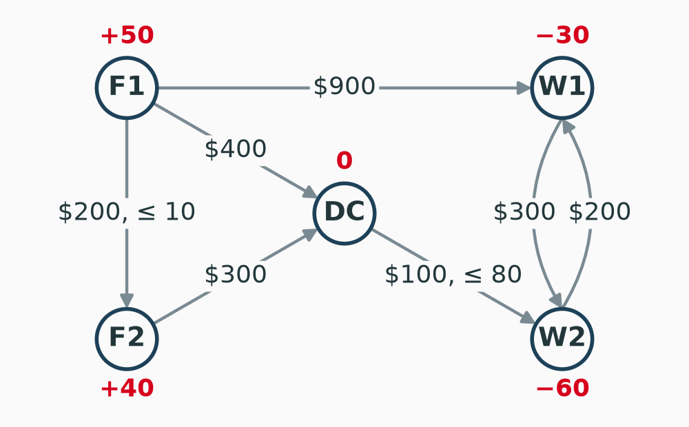

- Factories F1 and F2 make 50 and 40 units
- Warehouses W1 and W2 need 30 and 60
- Seven lanes, a cost per unit on each; F1→F2 carries at most 10 and DC→W2 at most 80
- **Decide** how much to ship on each lane, at least total cost

## The Model

$$\begin{alignat*}{3}
\min~ & \rlap{200x_{F1,F2} + 400x_{F1,DC} + 900x_{F1,W1} + 300x_{F2,DC}} \\
& \rlap{{} + 100x_{DC,W2} + 300x_{W1,W2} + 200x_{W2,W1}} \\[4pt]
\text{s.t.}~ & x_{F1,F2} + x_{F1,DC} + x_{F1,W1} & \quad & {}= 50 && \qquad \text{F1} \\
& x_{F2,DC} - x_{F1,F2} & \quad & {}= 40 && \qquad \text{F2} \\
& x_{DC,W2} - x_{F1,DC} - x_{F2,DC} & \quad & {}= 0 && \qquad \text{DC} \\
& x_{W1,W2} - x_{F1,W1} - x_{W2,W1} & \quad & {}= -30 && \qquad \text{W1} \\
& x_{W2,W1} - x_{DC,W2} - x_{W1,W2} & \quad & {}= -60 && \qquad \text{W2} \\
& x_{F1,F2} & \quad & {}\le 10 \\
& x_{DC,W2} & \quad & {}\le 80 \\
& x & \quad & {}\ge 0
\end{alignat*}$$

## The Optimal Shipments

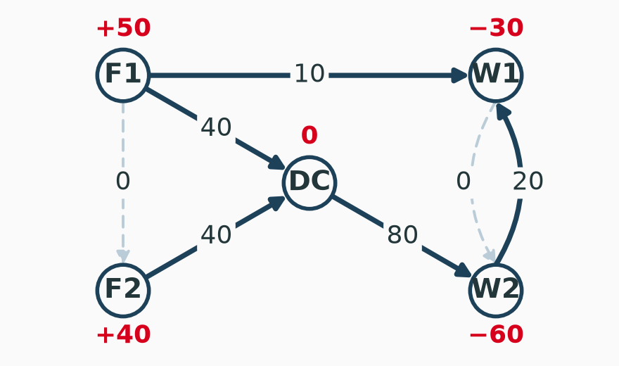

- DC→W2 runs **at capacity**: W2 keeps 60 and passes 20 on to W1
- W1 gets its other 10 straight from F1, the $900 lane
- F1→F2 and W1→W2 stay empty

$$900 \cdot 10 + 400 \cdot 40 + 300 \cdot 40 + 100 \cdot 80 + 200 \cdot 20
= \$49{,}000$$

## Node Prices

${p_i}$: the dual value of node ${i}$’s balance row (gurobipy).

| Node | F1 | F2 | DC | W1 | W2 |
| --- | --- | --- | --- | --- | --- |
| ${p_i}$ ($) | 900 | 800 | 500 | 0 | 200 |

- One more unit from F1 to W1 costs ${p_{F1} - p_{W1} = 900}$
- Reduced cost of a lane: ${c_{ij} - (p_i - p_j)}$
  - F1→F2: ${200 - (900 - 800) = 100}$, unused
  - W1→W2: ${300 - (0 - 200) = 500}$, unused
  - DC→W2: ${100 - (500 - 200) = -200}$: a unit of capacity saves $200

## The Workbook

**Download Distribution_Unlimited.xlsx and open it**

One sheet in arc-list form, opening at the optimum, $49,000, with Solver set up: objective cell orange, changing cells yellow, data blue.

Net flow = SUMIF over From − SUMIF over To; a new lane is a new row

| Block | Columns | Role |
| --- | --- | --- |
| Lanes | From, To, Ship, Capacity, Cost | One row per arc |
| Nodes | Node, Net flow, Supply | Net flow by SUMIF |
| Solver | Net flow = supply; Ship ≤ Capacity | Minimize, Simplex LP |

## Try It: How Sure Are the Costs?

**Download Distribution_Unlimited.xlsx and open it**

The unit costs are estimates. Re-solve and ask Solver for the **Sensitivity Report**.

1. For each lane, over what range of its cost does the plan stay optimal?
2. Which cost has the smallest margin for error?
3. What do the ranges tell management about where to check the estimates first?

## The Notebook [min_cost_flow.ipynb](https://colab.research.google.com/drive/1FW2gY1WVSw_2gH4Nbx1NOUASTBVnEjVf)

- The model once, as a function of node and arc data
- Distribution Unlimited, its node prices and a capacity what-if
- The delivery network’s shortest path and maximum flow as minimum cost flows
- Open in Colab, then File, Save a copy in Drive

```python
x = m.addVars(arcs.keys(), obj=cost, ub=capacity, name="x")
balance = m.addConstrs(
    (x.sum(i, "*") - x.sum("*", i) == supply[i] for i in supply),
    name="balance")
```

# Project Scheduling as an LP (Optional)

## Reliable Construction

A contractor must build a plant in 40 weeks or less to earn a bonus. Fourteen activities, from excavation (A) to the interior fixtures (N):

| Activity | A | B | C | D | E | F | G | H | I | J | K | L | M | N |
| --- | --- | --- | --- | --- | --- | --- | --- | --- | --- | --- | --- | --- | --- | --- |
| Weeks | 2 | 4 | 10 | 6 | 4 | 5 | 7 | 9 | 7 | 8 | 4 | 5 | 2 | 6 |
| After | none | A | B | C | C | E | D | E, G | C | F, I | J | J | H | K, L |

- “After”: the activities that must finish first
- How soon can the plant be done, and which activities set that date?

## The Project Network

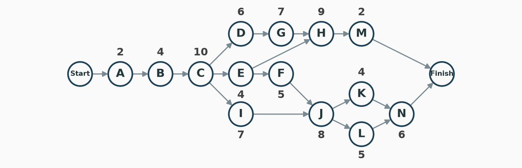

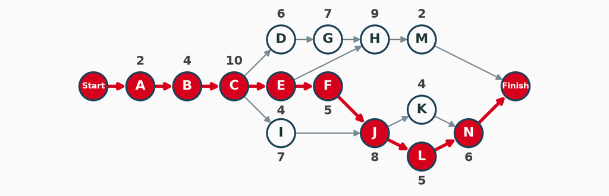

- Each activity is a node, with its weeks above it; an arc means “must finish before”
- Critical path: the longest path, A B C E F J L N, ${2 + 4 + 10 + 4 + 5 + 8 + 5 + 6 = 44}$ weeks

## Earliest Start Times, by Hand

| Activity | Earliest start (weeks) | Activity | Earliest start (weeks) |
| --- | --- | --- | --- |
| A | 0 | H | max(E: 16 + 4, G: 22 + 7) = 29 |
| B | A: 0 + 2 = 2 | I | C: 6 + 10 = 16 |
| C | B: 2 + 4 = 6 | J | max(F: 20 + 5, I: 16 + 7) = 25 |
| D | C: 6 + 10 = 16 | K | J: 25 + 8 = 33 |
| E | C: 6 + 10 = 16 | L | J: 25 + 8 = 33 |
| F | E: 16 + 4 = 20 | M | H: 29 + 9 = 38 |
| G | D: 16 + 6 = 22 | N | max(K: 33 + 4, L: 33 + 5) = 38 |
| Finish | **max(M: 38 + 2, N: 38 + 6) = 44** |  |  |

- An activity starts when **all** its predecessors finish: the max of their finish times
- 44 weeks against a 40-week deadline: the project must be sped up

## Two LPs for the Schedule

**Earliest finish.** ${s_j}$: start of ${j}$; ${d_j}$: its weeks; ${i \to j}$: ${i}$ first.

$$\begin{alignat*}{3}
\min~ & \rlap{T} \\[4pt]
\text{s.t.}~ & s_j & \quad & {}\ge s_i + d_i && \qquad i \to j \\
& T & \quad & {}\ge s_j + d_j && \qquad \text{every } j \\
& s & \quad & {}\ge 0
\end{alignat*}$$

gurobipy: ${T = 44}$.

**Time-cost trade-off** (Kelley, 1961). ${y_j}$: weeks cut from ${j}$, at ${k_j}$ dollars per week, at most ${R_j}$.

$$\begin{alignat*}{3}
\min~ & \rlap{\textstyle\sum_j k_j\, y_j} \\[4pt]
\text{s.t.}~ & s_j & \quad & {}\ge s_i + d_i - y_i && \qquad i \to j \\
& s_j + d_j - y_j & \quad & {}\le 40 && \qquad \text{every } j \\
& y_j & \quad & {}\le R_j && \qquad \text{every } j \\
& s, y & \quad & {}\ge 0
\end{alignat*}$$

# Practice: Minimum Cost Flow Formulations

## Practice: Formulate a Minimum Cost Flow

**Practice Problem**

Plant P1 makes 30 units and plant P2 makes 20. Customer C1 needs 25 and C2 needs 25. Shipping costs per unit:

| Lane | P1→H | P2→H | P1→C1 | H→C1 | H→C2 | P2→C2 |
| --- | --- | --- | --- | --- | --- | --- |
| Cost ($) | 2 | 3 | 6 | 2 | 4 | 5 |

The hub H passes units through; H→C1 carries at most 20.

**(a)** Draw the network with the net supply at each node.  
**(b)** Write the LP: one balance row per node, out minus in.  
**(c)** Solve it in Excel and check that the flows are integers. Which lane is the bottleneck?

## Practice: Which Special Case?

**Practice Problem**

For each problem, give the net supply ${b_i}$ of every node and the arcs’ costs and capacities that make it a minimum cost flow:

**(a)** The shortest path from O to T in the delivery network.

**(b)** The maximum number of truckloads per day from O to T.

**(c)** Three students are matched to three papers, one each, to maximize the total preference score.

**(d)** Why can the solution of (c) be found without integer constraints?

# Conclusions

## Summary of Part I

**Core takeaways**

- Shortest path algorithm: nearest first; the table records total distance and last connection
- Shortest path LP: send one unit
- Spanning tree: add the shortest link to an unconnected node

**Watch out for**

- Ties: solve both, keep both last connections
- Lengths must be nonnegative
- Greedy works for the tree and fails for the path

## Summary of Part II

**Core takeaways**

- Augment until no path has room
- Max flow = min cut
- Out minus in = ${b_i}$; integer data, integer flows

**Watch out for**

- Reverse arcs cancel flow
- One sign rule for every row

**Bottom line**

Draw the network first; the model follows from the picture.

## Questions?

Network Optimization

MGMT 6460

# Appendix: References and a Voluntary Problem

## Appendix: References

**Textbooks**  
Hillier, F. S. and Lieberman, G. J. *Introduction to Operations Research*, 11th ed. McGraw-Hill, 2021. Source of the delivery network (their Seervada Park), Distribution Unlimited, Reliable Construction and Speedy Airlines.

Ahuja, R. K., Magnanti, T. L. and Orlin, J. B. *Network Flows: Theory, Algorithms, and Applications*. Prentice Hall, 1993.

**Algorithms**  
Dijkstra, E. W. A note on two problems in connexion with graphs. *Numerische Mathematik* 1, 269–271, 1959. [doi:10.1007/BF01386390](https://doi.org/10.1007/BF01386390)

## Appendix: References, Continued

Ford, L. R. and Fulkerson, D. R. Maximal flow through a network. *Canadian Journal of Mathematics* 8, 399–404, 1956. [doi:10.4153/CJM-1956-045-5](https://doi.org/10.4153/CJM-1956-045-5)

Kruskal, J. B. On the shortest spanning subtree of a graph and the traveling salesman problem. *Proceedings of the American Mathematical Society* 7(1), 48–50, 1956. [doi:10.1090/S0002-9939-1956-0078686-7](https://doi.org/10.1090/S0002-9939-1956-0078686-7)

Prim, R. C. Shortest connection networks and some generalizations. *Bell System Technical Journal* 36(6), 1389–1401, 1957. [doi:10.1002/j.1538-7305.1957.tb01515.x](https://doi.org/10.1002/j.1538-7305.1957.tb01515.x)

Kelley, J. E. Critical-path planning and scheduling: mathematical basis. *Operations Research* 9(3), 296–320, 1961. [doi:10.1287/opre.9.3.296](https://doi.org/10.1287/opre.9.3.296)

## Appendix: Applications

Peters, K., Silva, S., Gonçalves, R., Kavelj, M., Fleuren, H., den Hertog, D., Ergun, O. and Freeman, M. The nutritious supply chain: optimizing humanitarian food assistance. *INFORMS Journal on Optimization* 3(2), 200–226, 2021. [doi:10.1287/ijoo.2019.0047](https://doi.org/10.1287/ijoo.2019.0047)

Peters, K., Silva, S., Wolter, T. S., Anjos, L., van Ettekoven, N., Combette, É., Melchiori, A., Fleuren, H., den Hertog, D. and Ergun, Ö. UN World Food Programme: toward zero hunger with analytics. *INFORMS Journal on Applied Analytics* 52(1), 8–26, 2022. [doi:10.1287/inte.2021.1097](https://doi.org/10.1287/inte.2021.1097)

## Appendix: Voluntary Problem

**Rebuild Optimus**

- Optimus joins two models you can now write: a **minimum cost flow** for the route and a **diet LP** for the food basket
- With AI tools, build a small what-if version. Change a price, a capacity or a nutrient target, re-solve, and explain what moved
- The formulation, the check with a solver and the interpretation are yours

**Read first:** Peters et al. (2022) for the application and Peters et al. (2021) for the model, both on the previous slide.  
**AI use:** cite the full exchange: date, tool, prompt and reply.